# Pandemic pressure and product quality. A time series perspective

Kerlijn Van Assche

2026-03-17

# Introduction

**Aim of the work:** To examine the temporal association between new COVID-19 cases and PQ-MP events and to identify whether increases in COVID-19 cases precede increases in PQ-MP events. The study uses cross-correlation analysis to explore potential lag structures between the two time series.

This document is an appendix to the doctoral thesis of Kerlijn Van Assche.

Full analytical sequence, following each step described in the method section for each time series pair. Please find R script and datasets on GitHub.

This script

- is only run on datasets that are not too sparse. (< 50% zero’s in the time-points)
- assesses stationarity of the data before proceeding
- applies prewhitening before analysing the time-series (takes into account stationarity and is applied to correct for autocorrelation)

  By using the *forecast* library in R, I can calculate the pre-withened *ccf* (code: [Chapter 8 Correlations and ARIMA | Time Series Analysis With R](https://nicolarighetti.github.io/Time-Series-Analysis-With-R/correlations-and-arima.html#cross-correlation); explanation: [How Auto ARIMA Works in R](https://mrinalcs.github.io/how-auto-arima-works)).

## Datasets

India

- All medical products
- COVID-19 medicines, Sanitisers and disinfectants

USA

- All medical products
- COVID-19 medicines, Sanitisers and disinfectants,COVID-19 diagnostics, Personal Protective Equipment (PPE)

## Sequence of the code for each dataset

- 1/ Data preparation
- 2/ Plotting - visualization of the data
- 3/ Cross-correlations (incl stationarity & autocorrelation)
  - **Step 0: Define the time series**
  - **Step1: Stationarity check and differencing**  
    Define if the Y-serie is stationary. If not, define the number of differencing that is required.)
    - Stationarity testing using the Augmented Dickey-Fuller (ADF) test
    - Differencing to achieve stationarity
  - **Step 2: Autocorrelation analysis using ACF and PACF.**  
    Verify the autocorrelation of the stationary data
  - **Step 3: baseline cross–correlation**
  - **Step 4. Prewhitened cross-correlation**
    - A/ **Prewhitening** (filtering and check model fit)  
      Using ARIMA modelling. To isolate genuine cross-correlations
    - B/ **Cross-correlation analysis using residuals**

# Pre-amble

## Load data

```r
#COVID-19 data
data_CV19_monthly <- read_csv("Data/data_CV19_monthly_IN-USA.csv")

#Poor-quality medical products data
data_mq <- read_csv("Data/data_mq_IN-USA.csv")
```

## Functions

#### Write a function to check stationarity

#### Load the function for data-preparation subsets

The function returns a dataset that contains information on the PQ-MQ events of interest and on the CV19-variable of interest for a specific geographical region.

# A. INDIA: assess cross-correlation

## A1. INDIA: Covid-19 cases & all MQ events

### 1.1. Data preparation

Prepare the dataset for INDIA: All medical products & new CV19 cases.

### 1.2. Plotting

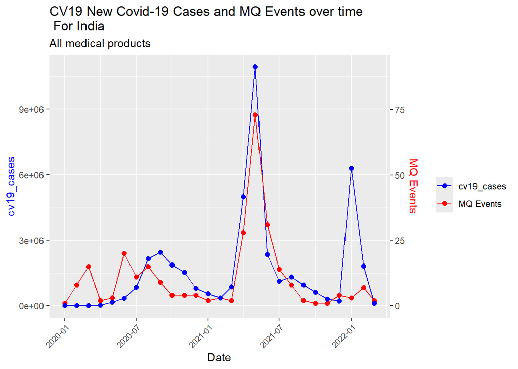

### 1.3. Cross-correlations (incl stationarity & autocorrelation)

**Highlights workflow**

- Need to account for autocorrelation and non-stationarity, which are common sources of spurious correlation.
- Apply pre-whitening to isolate genuine cross-correlations
- Validated model assumptions using residual diagnostics and the Ljung-Box test

For the X-series the analysis linked to the time-series itself is only performed once. This X - series (new CV19 cases) is is the same for all the datasets that include India.

#### Step 0: Define the time series

```r
###define the series that needs to be compared
x_series_CV19 <- joint_data$cv19_variable
y_series <- joint_data$mq_events
```

#### Step 1: Stationarity check and differencing

```r
##Check stationarity x-series
check_stationarity(x_series_CV19) #non-stationary
```

```
## ADF Statistic: -2.757763
## p-value: 0.2831787
## Alternative Hypothesis: stationary
## Non-stationary
```

```r
#1st time differencing
check_stationarity(diff(x_series_CV19)) #stationary
```

```
## ADF Statistic: -3.719459
## p-value: 0.04146722
## Alternative Hypothesis: stationary
## Stationary
```

```r
##Check stationarity y-series
check_stationarity (y_series) #non-stationary
```

```
## ADF Statistic: -2.323024
## p-value: 0.4491416
## Alternative Hypothesis: stationary
## Non-stationary
```

```r
#1st time differencing
check_stationarity(diff(y_series)) #non-stationary
```

```
## ADF Statistic: -3.221632
## p-value: 0.1069975
## Alternative Hypothesis: stationary
## Non-stationary
```

```r
#1st time differencing
check_stationarity(diff(diff(y_series))) #stationary
```

```
## ADF Statistic: -4.087412
## p-value: 0.02020657
## Alternative Hypothesis: stationary
## Stationary
```

```r
##################################
### Information for dataframe  ###
##################################

##Check stationarity x-series
stat_check_x <- adf_until_stationary(x_series_CV19)
print_check_stationarity(stat_check_x)
```

```
##
##  x_series_CV19
## Results original time-series:
##
##  Augmented Dickey-Fuller Test
##
## data:  time_series
## Dickey-Fuller = -2.7578, Lag order = 2, p-value = 0.2832
## alternative hypothesis: stationary
##
## Number of differencing required to obtain stationarity: 1
```

```r
#Define stationary x_series
x_series_CV19_s <- stat_check_x$transformed_series[[1]]


##Check stationarity y-series
stat_check_y <- adf_until_stationary(y_series)
print_check_stationarity(stat_check_y)
```

```
##
##  y_series
## Results original time-series:
##
##  Augmented Dickey-Fuller Test
##
## data:  time_series
## Dickey-Fuller = -2.323, Lag order = 2, p-value = 0.4491
## alternative hypothesis: stationary
##
## Number of differencing required to obtain stationarity: 2
```

```r
#Define stationary y_series
y_series_s <- stat_check_y$transformed_series[[1]]
```

#### Step 2: Autocorrelation analysis using ACF and PACF

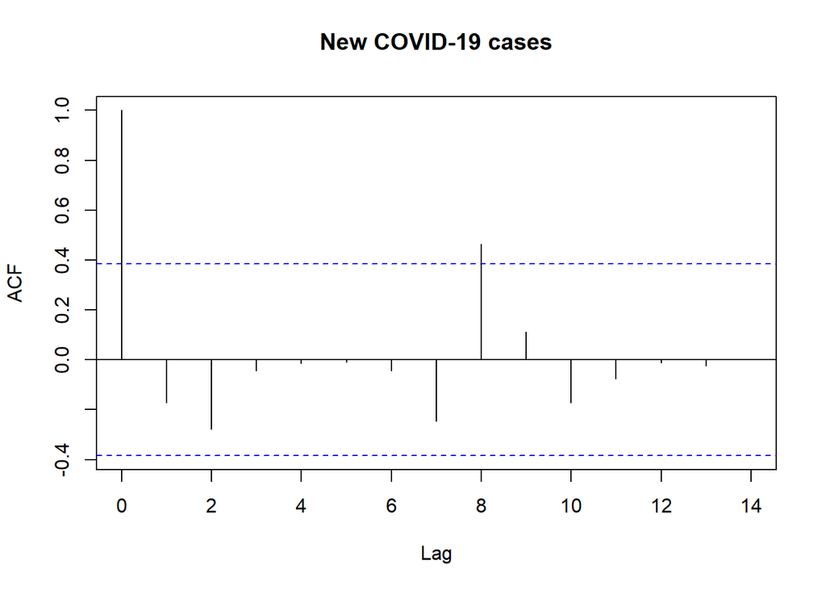

```r
##X-series
acf_x <- acf(x_series_CV19_s, main= "New COVID-19 cases")
```

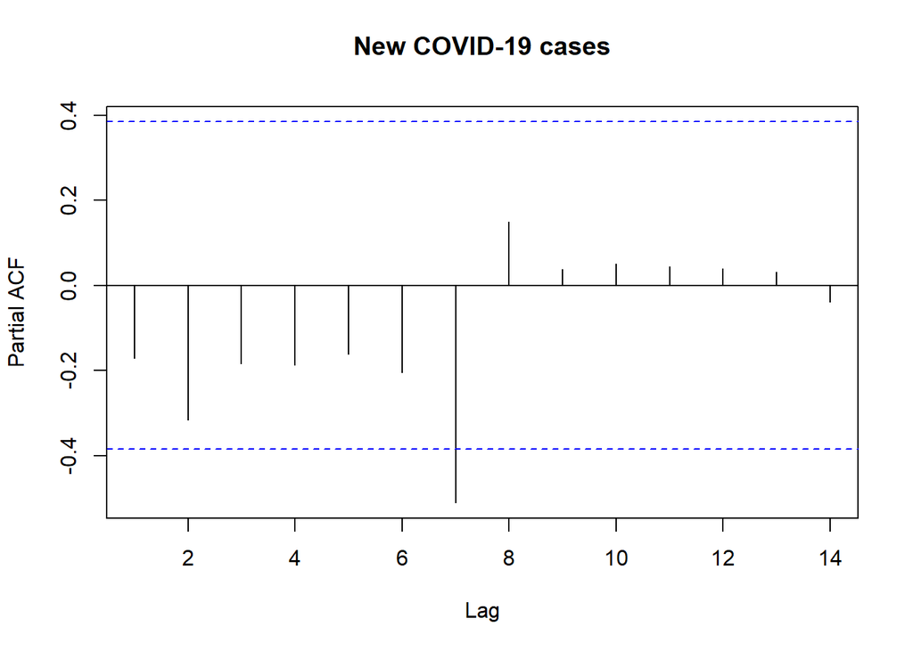

```r
pacf_x <- pacf(x_series_CV19_s, main= "New COVID-19 cases")
```

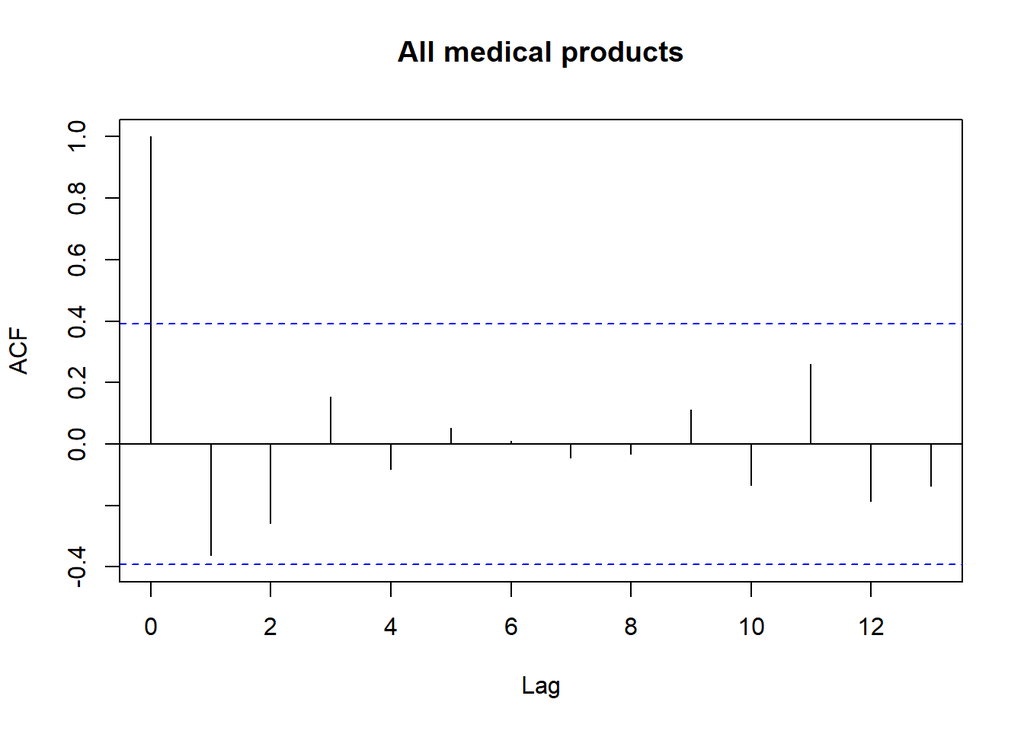

```r
##Y-series
acf_y <- acf(y_series_s, main= product_subset)
```

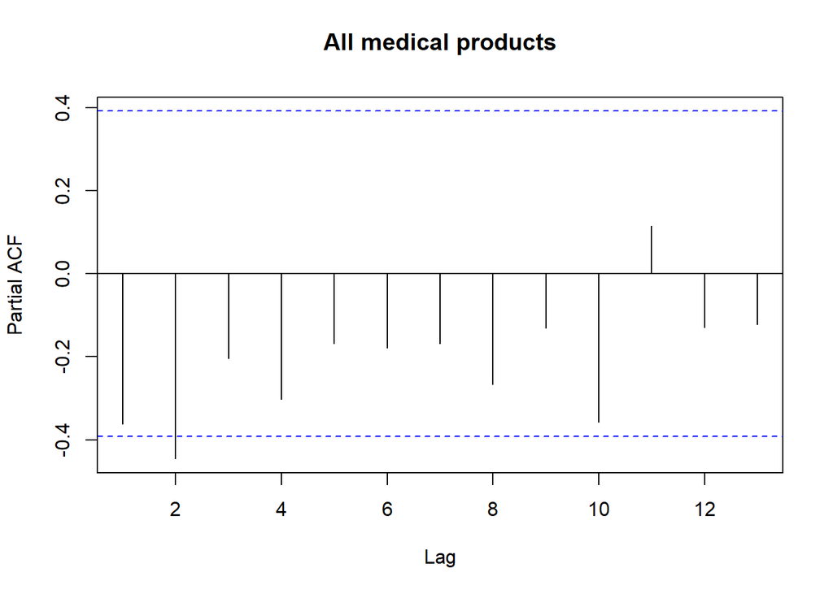

```r
pacf_y <- pacf(y_series_s, main= product_subset)
```

#### Step 3: baseline cross-correlation on stationary data

```r
###baseline cross-correlation on stationary data
baseline_ccf <- ccf(x_series_CV19_s, y_series_s, na.action = na.omit,
main = str_c("New COVID-19 cases (x) and ", product_subset, " (y)"), ylab = "baseline CCF")
```

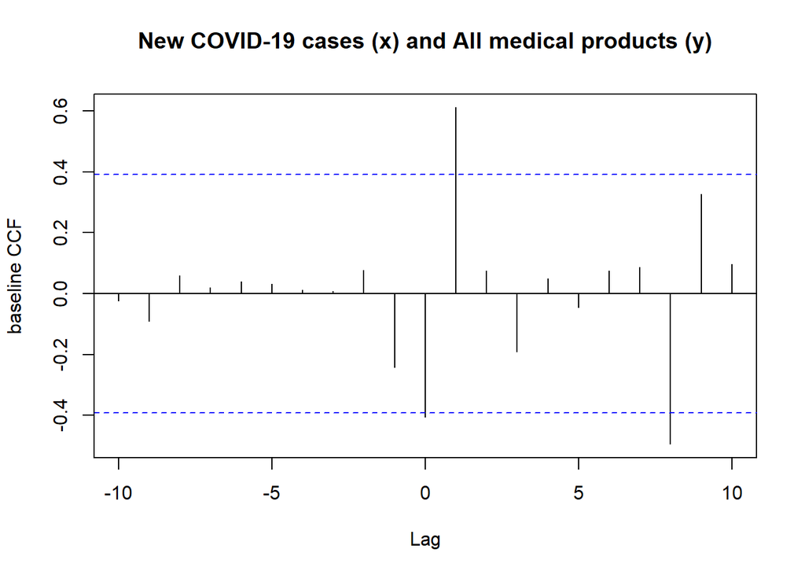

```
## # A tibble: 3 × 2
##      acf   lag
##    <dbl> <dbl>
## 1 -0.406     0
## 2  0.612     1
## 3 -0.495     8
```

```
## Significance threshold (95% CI):0.392
## The range of analysis: -10 to 10
## Significant lags:
```

#### Step 4: Prewhitened cross-correlation

##### Step 4A: Prewhitening

```r
###Steps to apply prewhitning before calculating the cross-correlation

# fit an ARIMA model
x_model <- auto.arima(x_series_CV19)
# keep the residuals ("white noise")
x_residuals_CV19 <- x_model$residuals

#fit the same ARIMA model to the Y-series by using the "Arima" function in forecast
y_model <- Arima(y_series_s, model=x_model)
# keep the residuals
y_filtered <- residuals(y_model)
```

Validate model assumptions using residual diagnostics and the Ljung-Box test

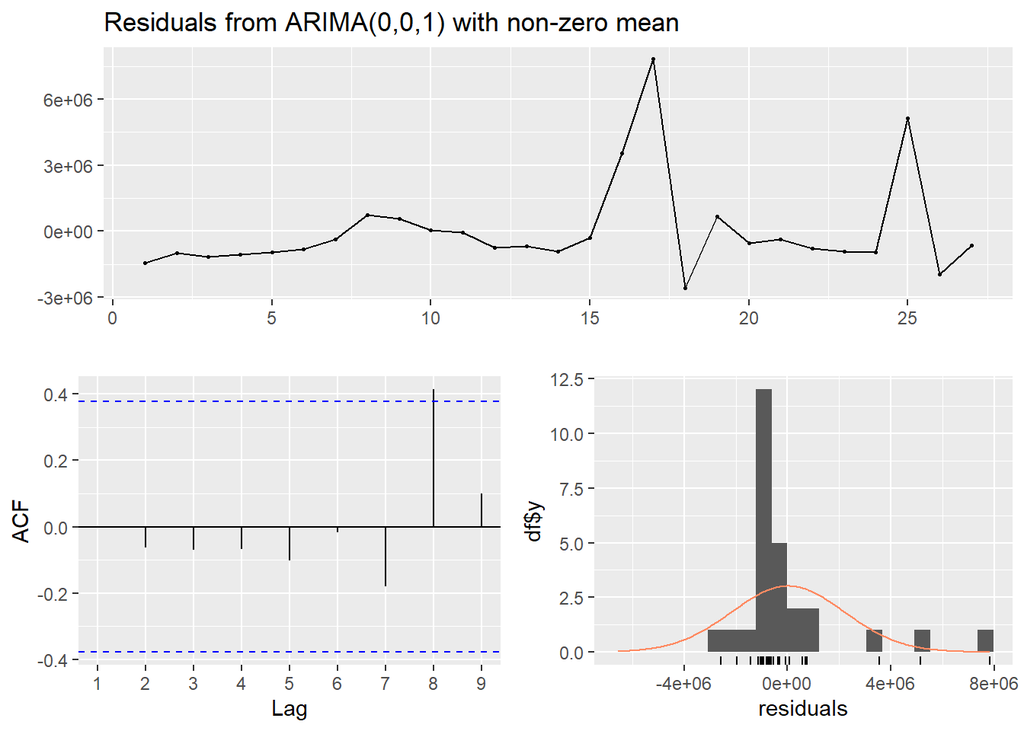

```
##
##  Ljung-Box test
##
## data:  Residuals from ARIMA(0,0,1) with non-zero mean
## Q* = 0.81466, df = 4, p-value = 0.9365
##
## Model df: 1.   Total lags used: 5
```

```r
##Analyze residuals to evaluate fit of the model - X-series
# acf(x_residuals_CV19)
# pacf(x_residuals_CV19)
# hist(x_residuals_CV19, main = "Histogram of residuals - x series (CV19 cases)")
checkresiduals(x_model)
```

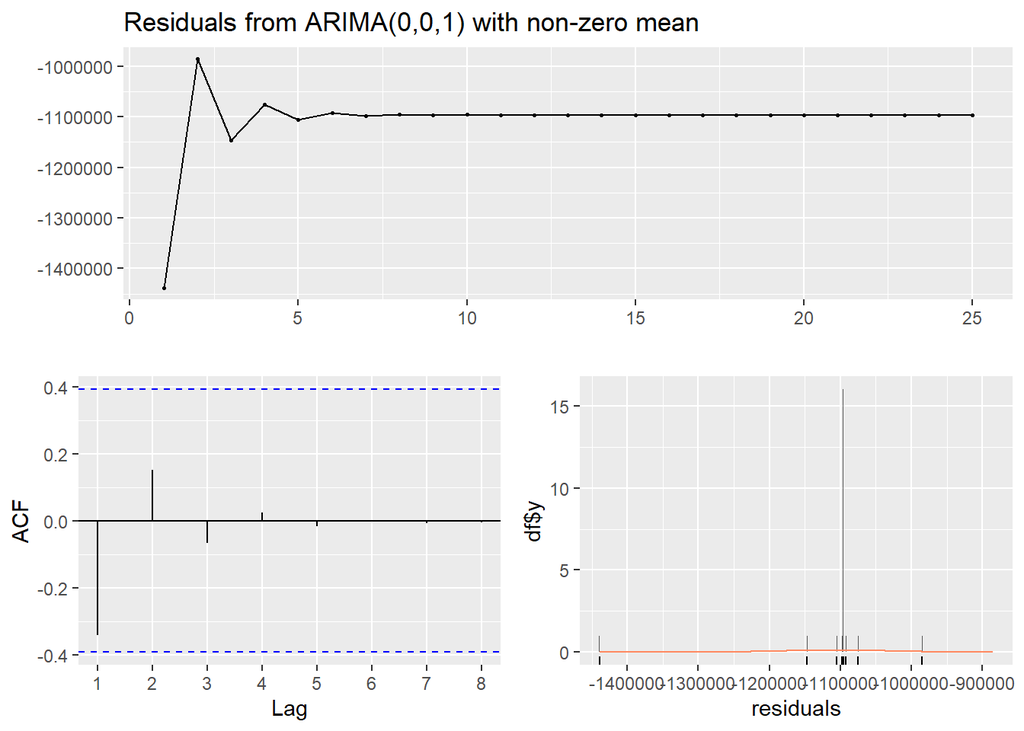

```
##
##  Ljung-Box test
##
## data:  Residuals from ARIMA(0,0,1) with non-zero mean
## Q* = 4.0903, df = 4, p-value = 0.3939
##
## Model df: 1.   Total lags used: 5
```

```r
##Analyze residuals to evaluate fit of the model - Y-series
# acf(y_filtered)
# pacf(y_filtered)
# hist(y_filtered, main = "Histogram of residuals - filtered y series (MQ events")
checkresiduals(y_model)
```

##### Step 4b: Cross-correlation analysis using residuals

Evaluate the correlation between residuals of X- and Y-series using the cross-correlation function

```r
# apply the ccf to the residuals
prewhiten_ccf <- ccf(x_residuals_CV19, y_filtered,
                     main = str_c("Filtered residuals of New COVID-19 cases (x) and ",
                                  product_subset, " (y)"),
                     ylab = "prewhitened CCF")
```

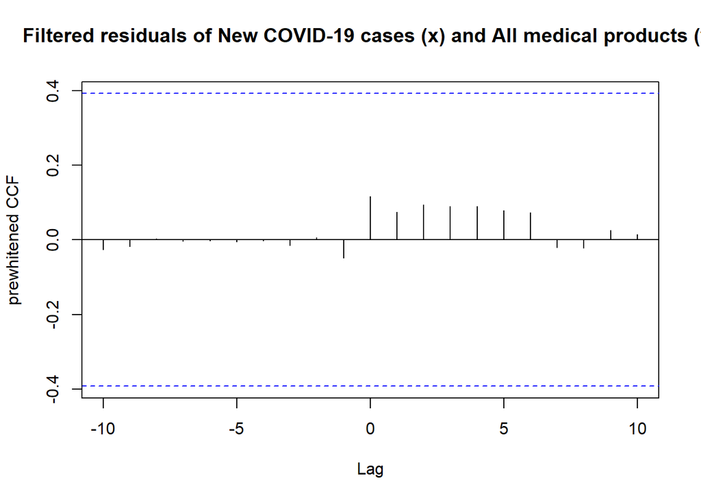

```
## Significance threshold (95% CI):0.392
## The range of analysis: -10 to 10
## Significant lags:
```

```
## # A tibble: 0 × 2
## # ℹ 2 variables: acf <dbl>, lag <dbl>
```

## A2. INDIA new COVID-19 cases & medicines

### 2.1. Data preparation

Prepare the dataset for INDIA: COVID-19 medicines, new CV19 cases.

### 2.2. Plotting

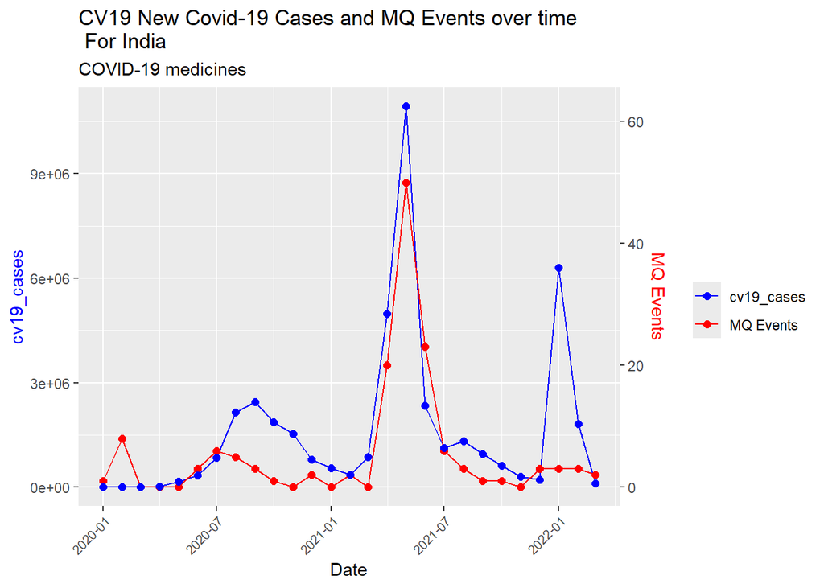

### 2.3. Cross-correlations (incl stationarity & autocorrelation)

#### Step 0: Define the time series

```r
####define the series that needs to be compared
x_series_CV19 <- joint_data$cv19_variable
y_series <- joint_data$mq_events
```

#### Step 1: Stationarity check and differencing

```r
# ##Check stationarity x-series
# check_stationarity(x_series_CV19) #non-stationary
# #1st time differencing
# check_stationarity(diff(x_series_CV19)) #stationary


##Check stationarity y-series
check_stationarity (y_series) #non-stationary
```

```
## ADF Statistic: -2.270538
## p-value: 0.469178
## Alternative Hypothesis: stationary
## Non-stationary
```

```r
#1st time differencing
check_stationarity(diff(y_series)) #non-stationary
```

```
## ADF Statistic: -3.262787
## p-value: 0.09683513
## Alternative Hypothesis: stationary
## Non-stationary
```

```r
#2nd time differencing
check_stationarity(diff(diff(y_series))) #stationary
```

```
## ADF Statistic: -4.100944
## p-value: 0.01973451
## Alternative Hypothesis: stationary
## Stationary
```

```r
##################################
### Information for dataframe  ###
##################################

# ##Check stationarity x-series
# stat_check_x <- adf_until_stationary(x_series_CV19)
# print_check_stationarity(stat_check_x)
# #Define stationary x_series
# x_series_CV19_s <- stat_check_x$transformed_series[[1]]


##Check stationarity y-series
stat_check_y <- adf_until_stationary(y_series)
print_check_stationarity(stat_check_y)
```

```
##
##  y_series
## Results original time-series:
##
##  Augmented Dickey-Fuller Test
##
## data:  time_series
## Dickey-Fuller = -2.2705, Lag order = 2, p-value = 0.4692
## alternative hypothesis: stationary
##
## Number of differencing required to obtain stationarity: 2
```

```r
#Define stationary y_series
y_series_s <- stat_check_y$transformed_series[[1]]
```

#### Step 2: Autocorrelation analysis using ACF and PACF

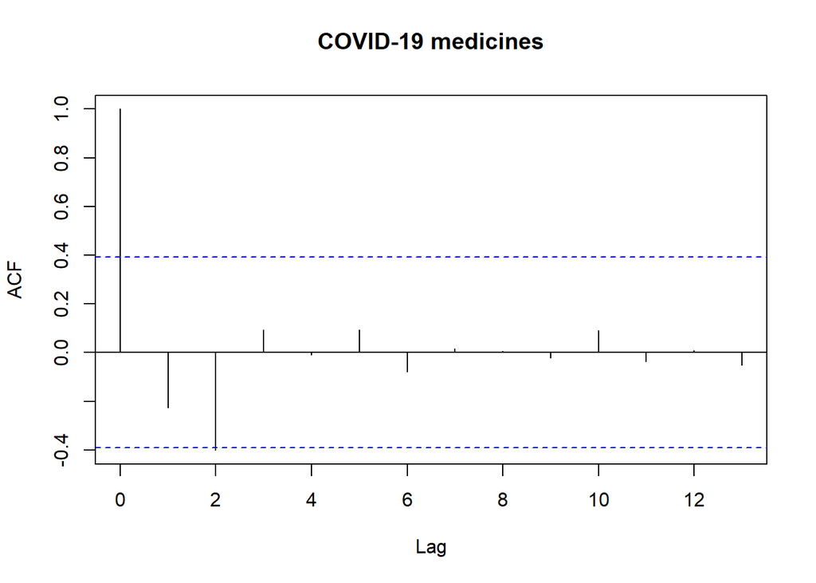

```r
# ##X-series
# acf_x <- acf(x_series_CV19_s, main= "New COVID-19 cases")
# pacf_x <- pacf(x_series_CV19_s, main= "New COVID-19 cases")

##Y-series
acf_y <- acf(y_series_s, main= product_subset)
```

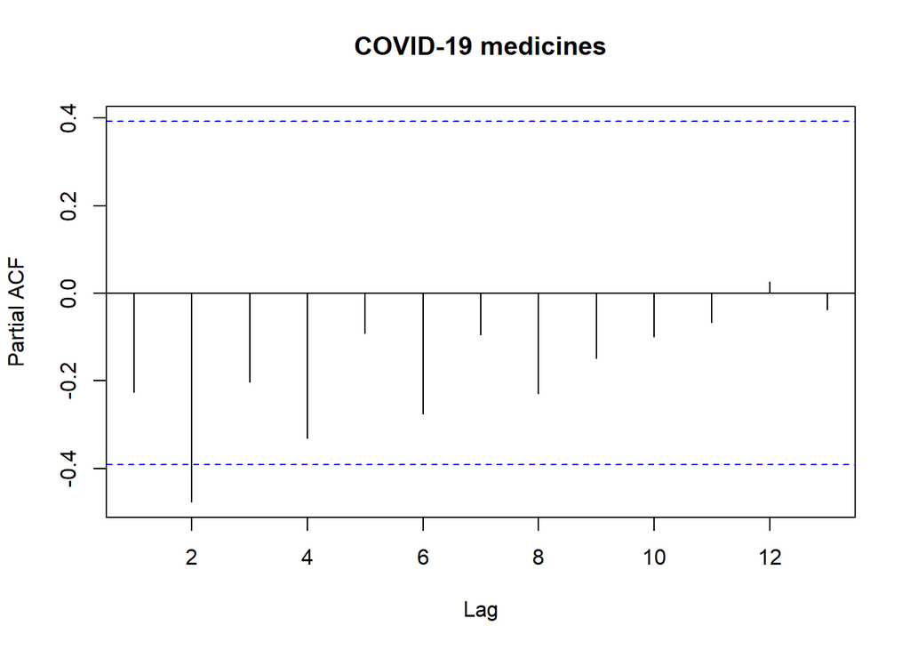

```r
pacf_y <- pacf(y_series_s, main= product_subset)
```

#### Step 3: baseline cross-correlation on stationary data

```r
###baseline cross-correlation on stationary data
baseline_ccf <- ccf(x_series_CV19_s, y_series_s, na.action = na.omit,
main = str_c("New COVID-19 cases (x) and ", product_subset, " (y)"), ylab = "baseline CCF")
```

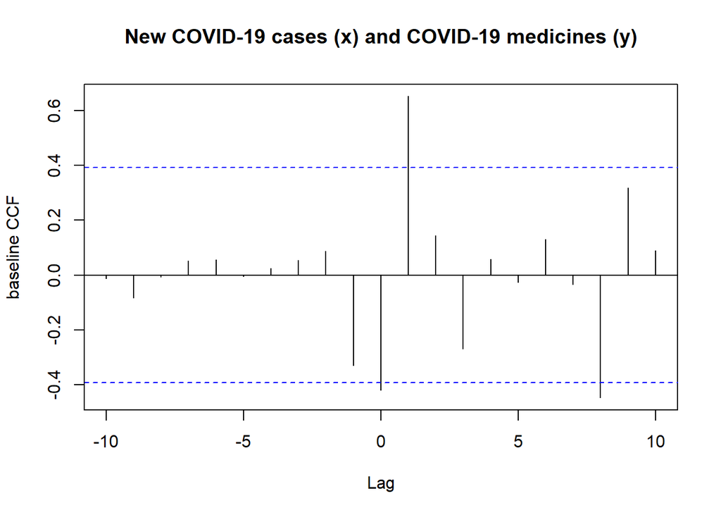

```r
baseline_ccf_in_med <- baseline_ccf
```

```
## # A tibble: 3 × 2
##      acf   lag
##    <dbl> <dbl>
## 1 -0.419     0
## 2  0.652     1
## 3 -0.447     8
```

```
## Significance threshold (95% CI):0.392
## The range of analysis: -10 to 10
## Significant lags:
```

#### Step 4: Prewhitened cross-correlation

##### Step 4A: Prewhitening

```r
###Steps to apply prewhitning before calculating the cross-correlation

# # fit an ARIMA model
# x_model <- auto.arima(x_series_CV19)
# # keep the residuals ("white noise")
# x_residuals_CV19 <- x_model$residuals

#fit the same ARIMA model to the Y-series by using the "Arima" function in forecast
y_model <- Arima(y_series_s, model=x_model)
# keep the residuals
y_filtered <- residuals(y_model)
```

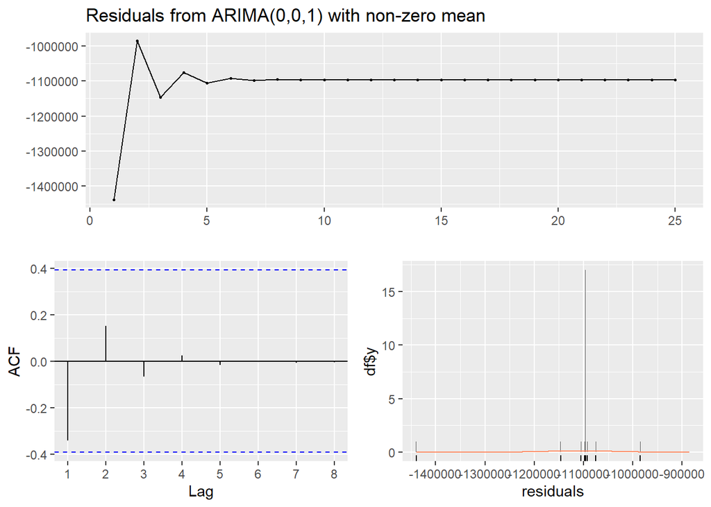

```
##
##  Ljung-Box test
##
## data:  Residuals from ARIMA(0,0,1) with non-zero mean
## Q* = 4.0918, df = 4, p-value = 0.3937
##
## Model df: 1.   Total lags used: 5
```

```r
##Analyze residuals to evaluate fit of the model - X-series
# acf(x_residuals_CV19)
# pacf(x_residuals_CV19)
# hist(x_residuals_CV19, main = "Histogram of residuals - x series (CV19 cases)")
# x_check <- checkresiduals(x_model)
# x_check_in_med <- x_check

##Analyze residuals to evaluate fit of the model - Y-series
# acf(y_filtered)
# pacf(y_filtered)
# hist(y_filtered, main = "Histogram of residuals - filtered y series (MQ events")
checkresiduals(y_model)
```

##### Step 4b: Cross-correlation analysis using residuals

Evaluate the correlation between residuals of X- and Y-series using the cross-correlation function

```r
# apply the ccf to the residuals
prewhiten_ccf <- ccf(x_residuals_CV19, y_filtered,
                     main = str_c("Filtered residuals of New COVID-19 cases (x) and ",
                                  product_subset, " (y)"),
                     ylab = "prewhitened CCF")
```

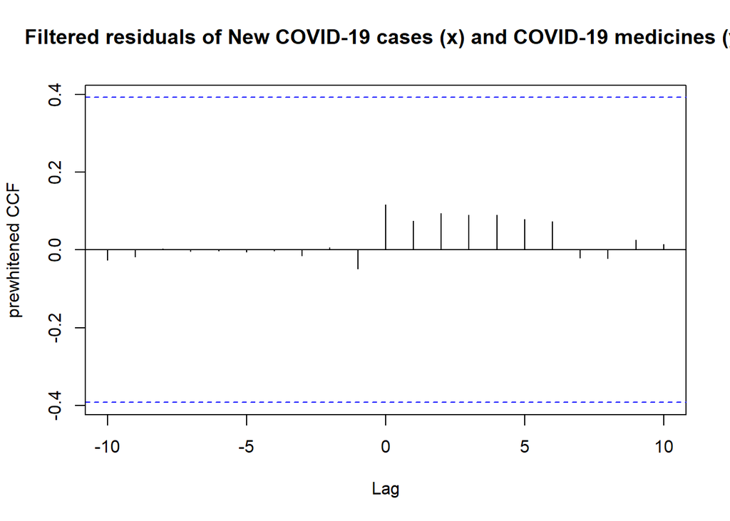

```
## Significance threshold (95% CI):0.392
## The range of analysis: -10 to 10
## Significant lags:
```

```
## # A tibble: 0 × 2
## # ℹ 2 variables: acf <dbl>, lag <dbl>
```

## A3. INDIA Covid-19 cases & sanitisers

### 3.1. Data preparation

Prepare the dataset for INDIA: sanitisers & cv19-cases

### 3.2. Plotting

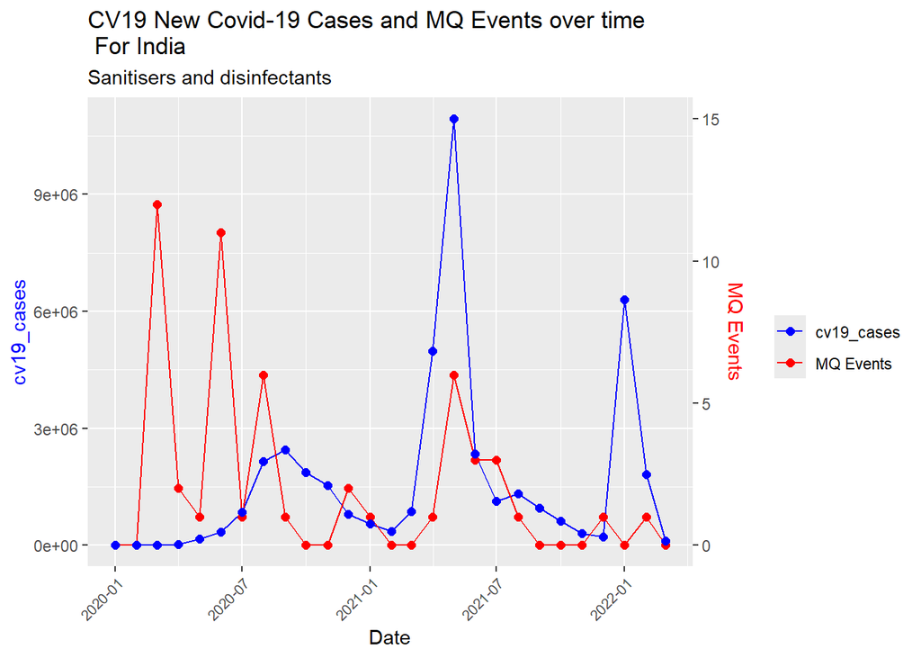

### 3.3. Cross-correlations (incl stationarity & autocorrelation)

#### Step 0: Define the time series

```r
####define the series that needs to be compared
x_series_CV19 <- joint_data$cv19_variable
y_series <- joint_data$mq_events
```

#### Step 1: Stationarity check and differencing

```r
# ##Check stationarity x-series
# check_stationarity(x_series_CV19) #non-stationary
# #1st time differencing
# check_stationarity(diff(x_series_CV19)) #stationary


##Check stationarity y-series
check_stationarity (y_series) #non-stationary
```

```
## ADF Statistic: -2.06581
## p-value: 0.5473335
## Alternative Hypothesis: stationary
## Non-stationary
```

```r
#1st time differencing
check_stationarity(diff(y_series)) #stationary
```

```
## ADF Statistic: -3.767426
## p-value: 0.03804097
## Alternative Hypothesis: stationary
## Stationary
```

```r
##################################
### Information for dataframe  ###
##################################

# ##Check stationarity x-series
# stat_check_x <- adf_until_stationary(x_series_CV19)
# print_check_stationarity(stat_check_x)
# #Define stationary x_series
# x_series_CV19_s <- stat_check_x$transformed_series[[1]]


##Check stationarity y-series
stat_check_y <- adf_until_stationary(y_series)
print_check_stationarity(stat_check_y)
```

```
##
##  y_series
## Results original time-series:
##
##  Augmented Dickey-Fuller Test
##
## data:  time_series
## Dickey-Fuller = -2.0658, Lag order = 2, p-value = 0.5473
## alternative hypothesis: stationary
##
## Number of differencing required to obtain stationarity: 1
```

```r
#Define stationary y_series
y_series_s <- stat_check_y$transformed_series[[1]]
```

#### Step 2: Autocorrelation analysis using ACF and PACF

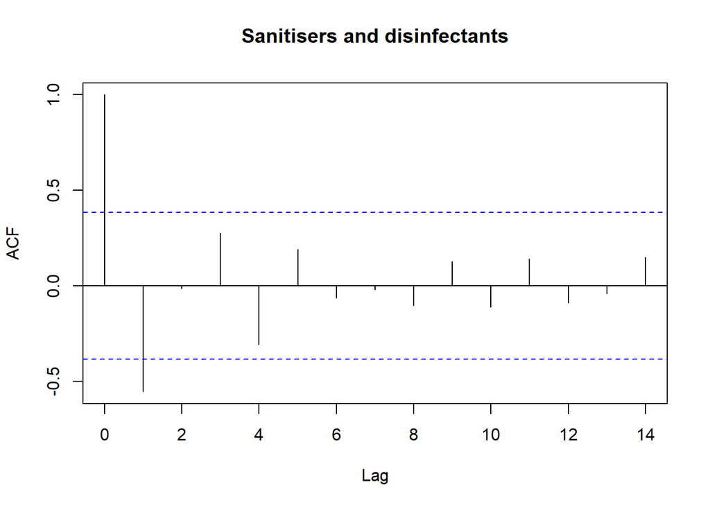

```r
# ##X-series
# acf_x <- acf(x_series_CV19_s, main= "New COVID-19 cases")
# pacf_x <- pacf(x_series_CV19_s, main= "New COVID-19 cases")

##Y-series
acf_y <- acf(y_series_s, main= product_subset)
```

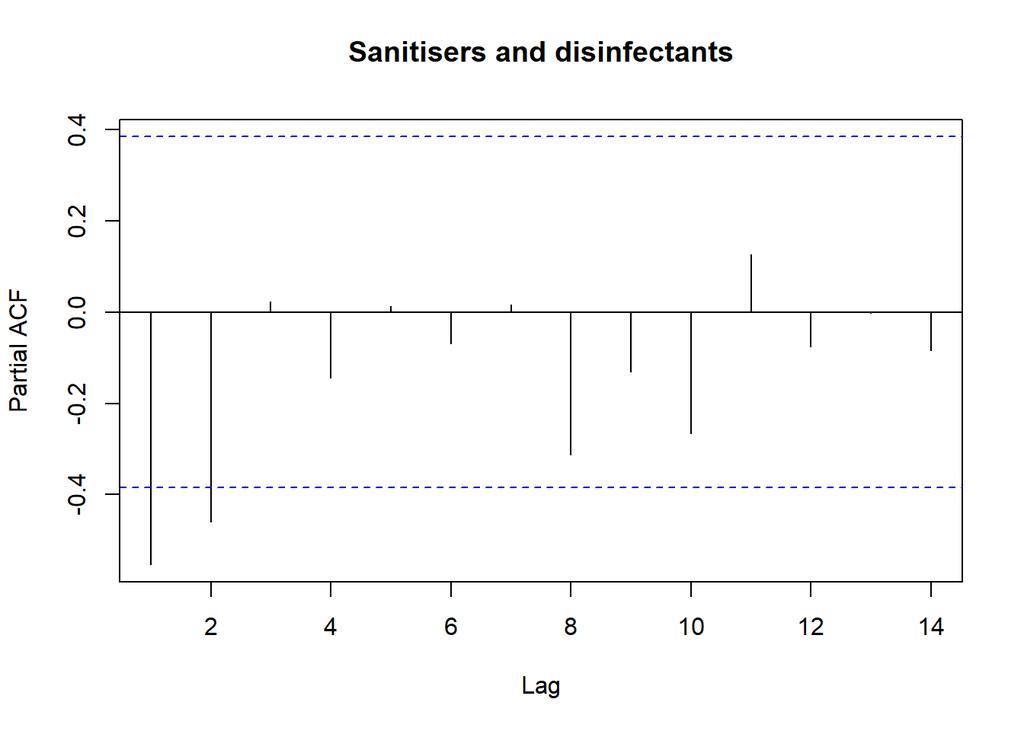

```r
pacf_y <- pacf(y_series_s, main= product_subset)
```

#### Step 3: baseline cross-correlation on stationary data

```r
###baseline cross-correlation on stationary data
baseline_ccf <- ccf(x_series_CV19_s, y_series_s, na.action = na.omit,
main = str_c("New COVID-19 cases (x) and ", product_subset, " (y)"), ylab = "baseline CCF")
```

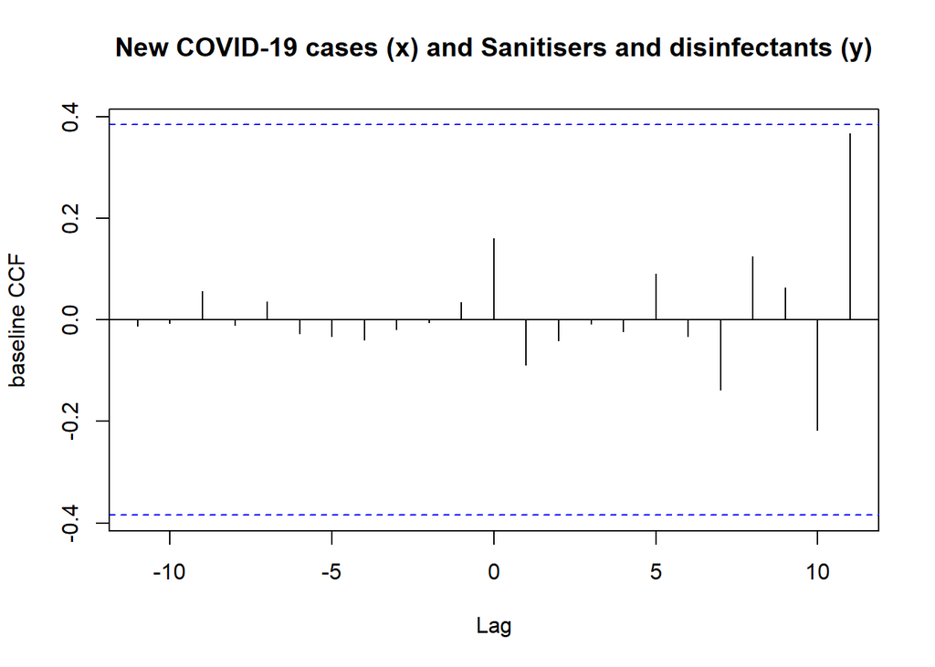

```r
baseline_ccf_in_san <- baseline_ccf
```

```
## # A tibble: 0 × 2
## # ℹ 2 variables: acf <dbl>, lag <dbl>
```

```
## Significance threshold (95% CI):0.3843876
## The range of analysis: -11 to 11
## Significant lags:
```

#### Step 4: Prewhitened cross-correlation

As there is no cross-correlation detected for the baseline CCF, no need to proceed and perform prewhitening.

============================================================

# B. USA

Datasets to look at:

USA

- all
- medicines, sanitizers, diagnostics, ppe

## B1. USA: Covid-19 cases & all MQ events

### B1.1. Data preparation

Prepare the dataset for USA , all MQ events combined, cv19-cases

### B1.2. Plotting

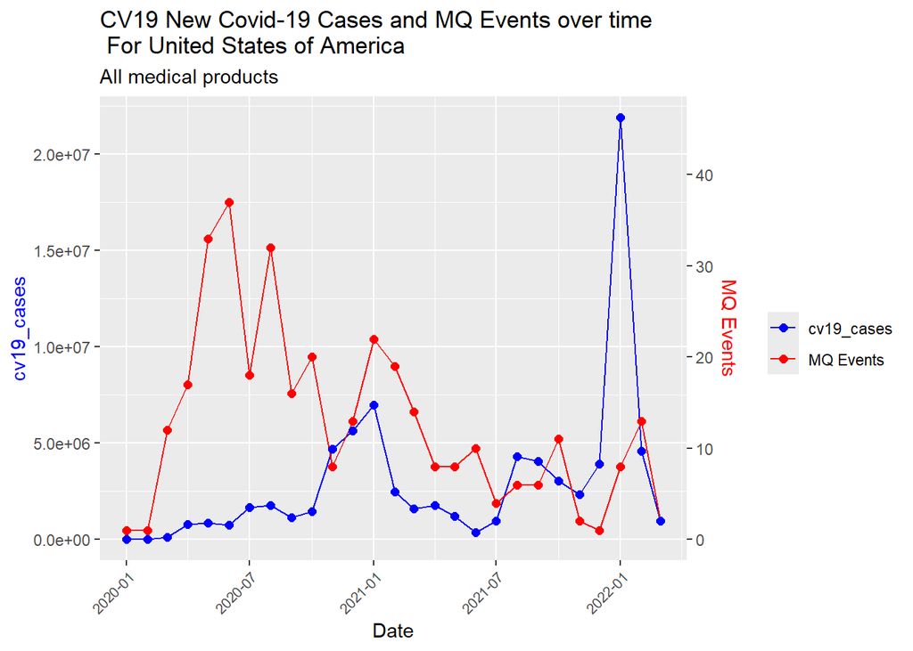

### B1.3. Cross-correlations (incl stationarity & autocorrelation)

#### Step 0: Define the time series

```r
###define the series that needs to be compared
x_series_CV19 <- joint_data$cv19_variable
y_series <- joint_data$mq_events
```

#### Step 1: Stationarity check and differencing

```r
##Check stationarity x-series
check_stationarity(x_series_CV19) #non-stationary
```

```
## ADF Statistic: -2.121729
## p-value: 0.5259864
## Alternative Hypothesis: stationary
## Non-stationary
```

```r
#1st time differencing
check_stationarity(diff(x_series_CV19)) #stationary
```

```
## ADF Statistic: -4.06336
## p-value: 0.02104559
## Alternative Hypothesis: stationary
## Stationary
```

```r
##Check stationarity y-series
check_stationarity(y_series) #stationary
```

```
## ADF Statistic: -4.07818
## p-value: 0.02028421
## Alternative Hypothesis: stationary
## Stationary
```

```r
##################################
### Information for dataframe  ###
##################################

##Check stationarity x-series
stat_check_x <- adf_until_stationary(x_series_CV19)
print_check_stationarity(stat_check_x)
```

```
##
##  x_series_CV19
## Results original time-series:
##
##  Augmented Dickey-Fuller Test
##
## data:  time_series
## Dickey-Fuller = -2.1217, Lag order = 2, p-value = 0.526
## alternative hypothesis: stationary
##
## Number of differencing required to obtain stationarity: 1
```

```r
#Define stationary x_series
x_series_CV19_s <- stat_check_x$transformed_series[[1]]


##Check stationarity y-series
stat_check_y <- adf_until_stationary(y_series)
print_check_stationarity(stat_check_y)
```

```
##
##  y_series
## Results original time-series:
##
##  Augmented Dickey-Fuller Test
##
## data:  time_series
## Dickey-Fuller = -4.0782, Lag order = 2, p-value = 0.02028
## alternative hypothesis: stationary
##
## Number of differencing required to obtain stationarity: 0
```

```r
#Define stationary y_series
y_series_s <- stat_check_y$transformed_series[[1]]
```

#### Step 2: Autocorrelation analysis using ACF and PACF

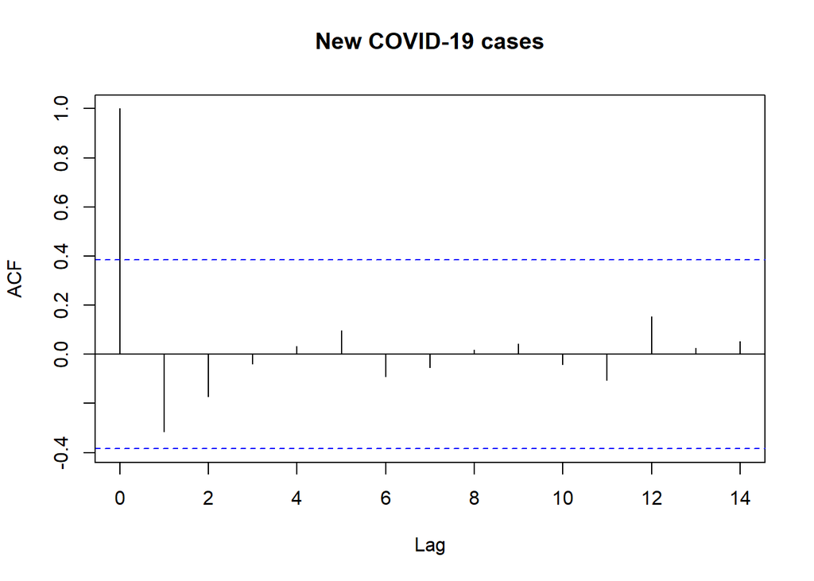

```r
##X-series
acf_x <- acf(x_series_CV19_s, main= "New COVID-19 cases")
```

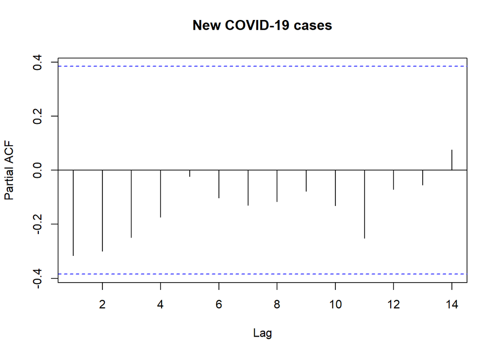

```r
pacf_x <- pacf(x_series_CV19_s, main= "New COVID-19 cases")
```

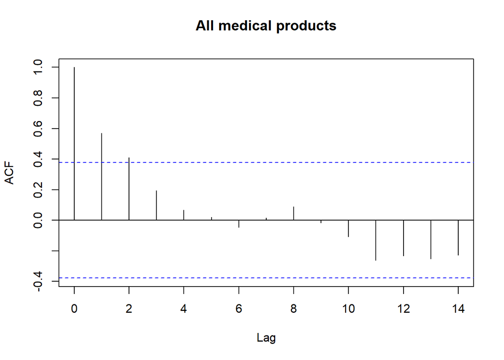

```r
##Y-series
acf_y <- acf(y_series_s, main= product_subset)
```

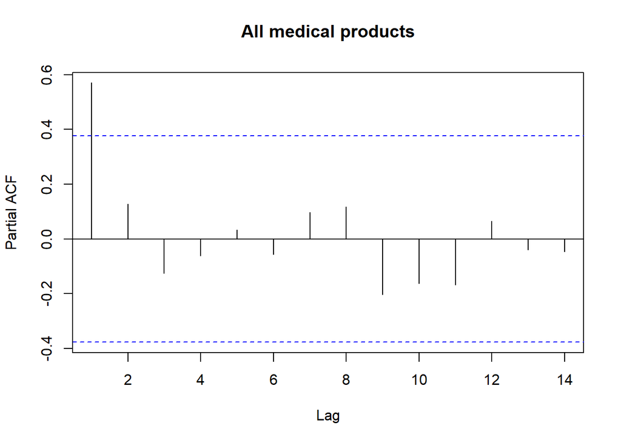

```r
pacf_y <- pacf(y_series_s, main= product_subset)
```

#### Step 3: baseline cross-correlation on stationary data

```r
###baseline cross-correlation on stationary data
baseline_ccf <- ccf(x_series_CV19_s, y_series_s, na.action = na.omit,
main = str_c("New COVID-19 cases (x) and ", product_subset, " (y)"), ylab = "baseline CCF")
```

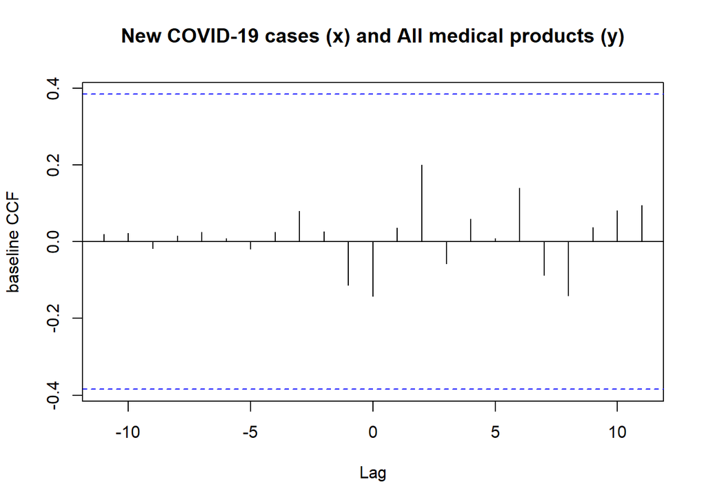

```
## # A tibble: 0 × 2
## # ℹ 2 variables: acf <dbl>, lag <dbl>
```

```
## Significance threshold (95% CI):0.3843876
## The range of analysis: -11 to 11
## Significant lags:
```

#### Step 4: Prewhitened cross-correlation

As there is no cross-correlation detected for the baseline CCF, no need to proceed and perform prewhitening.

## B2. USA: Covid-19 cases & medicines

### B2.1. Data preparation

Prepare the dataset for USA, medicines, CV19 cases

### B2.2. Plotting

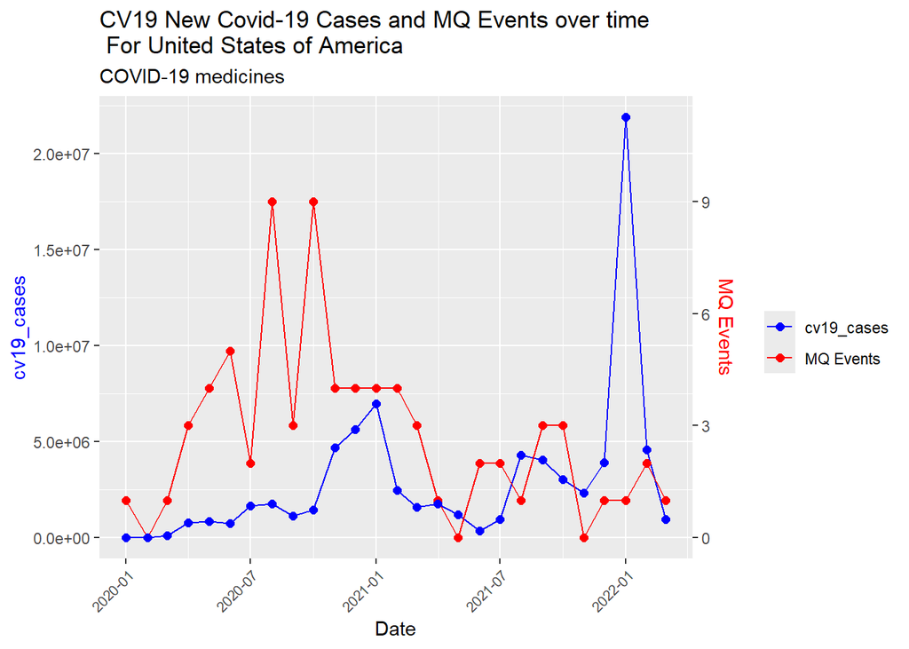

### B2.3. Cross-correlations (incl stationarity & autocorrelation)

#### Step 0: Define the time series

```r
####define the series that needs to be compared
x_series_CV19 <- joint_data$cv19_variable
y_series <- joint_data$mq_events
```

#### Step 1: Stationarity check and differencing

```r
##Check stationarity x-series
check_stationarity(x_series_CV19) #non-stationary
```

```
## ADF Statistic: -2.121729
## p-value: 0.5259864
## Alternative Hypothesis: stationary
## Non-stationary
```

```r
#1st time differencing
check_stationarity(diff(x_series_CV19)) #stationary
```

```
## ADF Statistic: -4.06336
## p-value: 0.02104559
## Alternative Hypothesis: stationary
## Stationary
```

```r
##Check stationarity y-series
check_stationarity (y_series) #non-stationary
```

```
## ADF Statistic: -2.964909
## p-value: 0.2041004
## Alternative Hypothesis: stationary
## Non-stationary
```

```r
#1st time differencing
check_stationarity(diff(y_series)) #non-stationary
```

```
## ADF Statistic: -3.118945
## p-value: 0.1461164
## Alternative Hypothesis: stationary
## Non-stationary
```

```r
#2nd time differencing
check_stationarity(diff(diff(y_series))) #stationary
```

```
## ADF Statistic: -5.381045
## p-value: 0.01
## Alternative Hypothesis: stationary
## Stationary
```

```r
##################################
### Information for dataframe  ###
##################################

# ##Check stationarity x-series
# stat_check_x <- adf_until_stationary(x_series_CV19)
# print_check_stationarity(stat_check_x)
# #Define stationary x_series
# x_series_CV19_s <- stat_check_x$transformed_series[[1]]


##Check stationarity y-series
stat_check_y <- adf_until_stationary(y_series)
print_check_stationarity(stat_check_y)
```

```
##
##  y_series
## Results original time-series:
##
##  Augmented Dickey-Fuller Test
##
## data:  time_series
## Dickey-Fuller = -2.9649, Lag order = 2, p-value = 0.2041
## alternative hypothesis: stationary
##
## Number of differencing required to obtain stationarity: 2
```

```r
#Define stationary y_series
y_series_s <- stat_check_y$transformed_series[[1]]
```

#### Step 2: Autocorrelation analysis using ACF and PACF

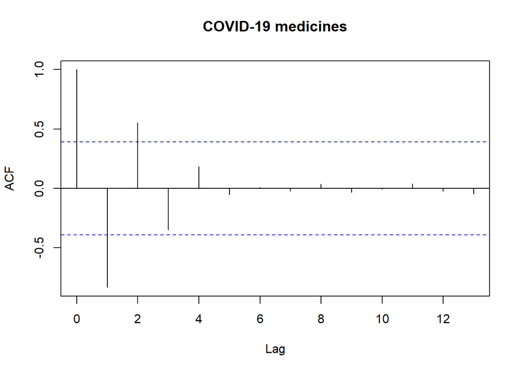

```r
# ##X-series
# acf_x <- acf(x_series_CV19_s, main= "New COVID-19 cases")
# pacf_x <- pacf(x_series_CV19_s, main= "New COVID-19 cases")

##Y-series
acf_y <- acf(y_series_s, main= product_subset)
```

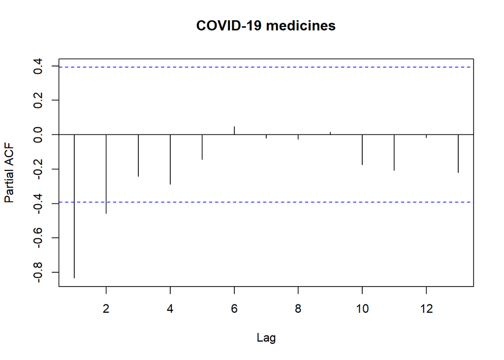

```r
pacf_y <- pacf(y_series_s, main= product_subset)
```

#### Step 3: baseline cross-correlation on stationary data

```r
###baseline cross-correlation on stationary data
baseline_ccf <- ccf(x_series_CV19_s, y_series_s, na.action = na.omit,
main = str_c("New COVID-19 cases (x) and ", product_subset, " (y)"), ylab = "baseline CCF")
```

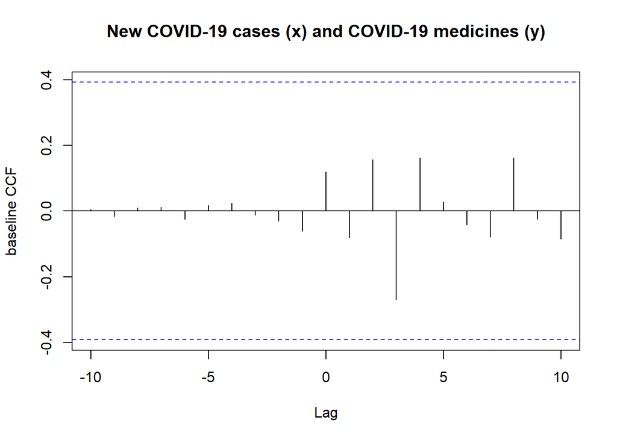

```
## # A tibble: 0 × 2
## # ℹ 2 variables: acf <dbl>, lag <dbl>
```

```
## Significance threshold (95% CI):0.392
## The range of analysis: -10 to 10
## Significant lags:
```

#### Step 4: Prewhitened cross-correlation

As there is no cross-correlation detected for the baseline CCF, no need to proceed and perform prewhitening.

## B3. USA: Covid-19 cases & sanitizers

### B3.1. Data preparation

Prepare the dataset for USA, hand-sanitizers, CV19 cases

### B3.2. Plotting

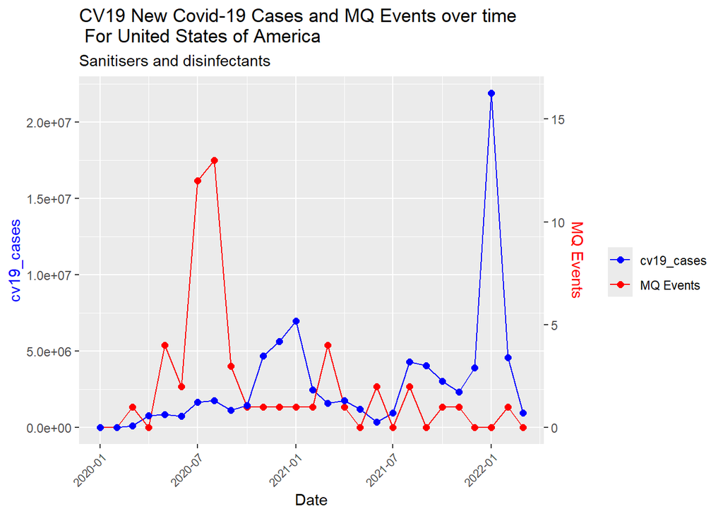

### B3.3. Cross-correlations (incl stationarity & autocorrelation)

#### Step 0: Define the time series

```r
####define the series that needs to be compared
x_series_CV19 <- joint_data$cv19_variable
y_series <- joint_data$mq_events
```

#### Step 1: Stationarity check and differencing

```r
# ##Check stationarity x-series
# check_stationarity(x_series_CV19) #non-stationary
# #1st time differencing
# check_stationarity(diff(x_series_CV19)) #stationary

##Check stationarity y-series
check_stationarity (y_series) #non-stationary
```

```
## ADF Statistic: -2.908313
## p-value: 0.2257061
## Alternative Hypothesis: stationary
## Non-stationary
```

```r
#1st time differencing
check_stationarity(diff(y_series)) #non-stationary
```

```
## ADF Statistic: -3.267856
## p-value: 0.09613114
## Alternative Hypothesis: stationary
## Non-stationary
```

```r
#2nd time differencing
check_stationarity(diff(diff(y_series))) #stationary
```

```
## ADF Statistic: -4.24553
## p-value: 0.01469082
## Alternative Hypothesis: stationary
## Stationary
```

#### Step 2: Autocorrelation analysis using ACF and PACF

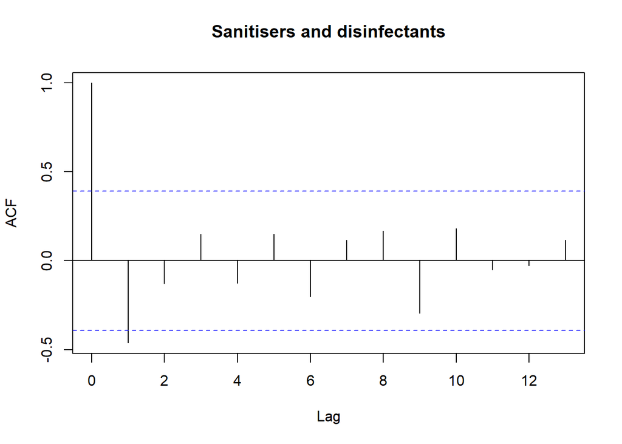

```r
# ##X-series
# acf_x <- acf(x_series_CV19_s, main= "New COVID-19 cases")
# pacf_x <- pacf(x_series_CV19_s, main= "New COVID-19 cases")

##Y-series
acf_y <- acf(y_series_s, main= product_subset)
```

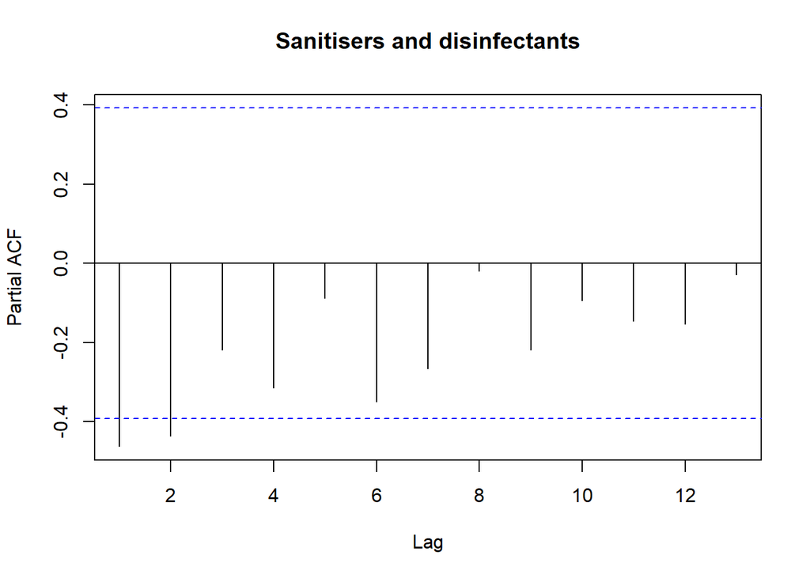

```r
pacf_y <- pacf(y_series_s, main= product_subset)
```